# M4_W3_L3_Working_With_Colour_In R_Plots

Alexander Cormack

2022-12-04

# Working With Colours In R Plots

## Plotting and colour in R

- The default colour schemes for most plots in R are horrendous
- Recently [sic] there have been developments to improve the handling / specification of colours in plots / graphs / etc.
- There are functions in R and in external packages that are very handy

## Colour utilities in R

- The **grDevices** package has two functions
  - colorRamp
  - colorRampPalette
- These functions take palettes of colours and help to interpolate between the colours
- The function colors() lists the names of colours you can use in any plotting function

## Colour palette utilities in R

- colorRamp: take a palette of colours and return a function that takes values between 0 and 1, indicating the extremes of the colour palette (e.g., see the ‘gray’ function)
- colorRampPalette: take a palette of colours and return a function that takes integer arguments and returns a vector of colours interpolating the palette (like heat.colors or topo.colors)

### colorRamp

```r
pal <- colorRamp(c("red", "blue"))
pal(0)
```

```
##      [,1] [,2] [,3]
## [1,]  255    0    0
```

```r
pal(1)
```

```
##      [,1] [,2] [,3]
## [1,]    0    0  255
```

```r
pal(0.5)
```

```
##       [,1] [,2]  [,3]
## [1,] 127.5    0 127.5
```

```r
pal(seq(0, 1, len = 10))
```

```
##            [,1] [,2]      [,3]
##  [1,] 255.00000    0   0.00000
##  [2,] 226.66667    0  28.33333
##  [3,] 198.33333    0  56.66667
##  [4,] 170.00000    0  85.00000
##  [5,] 141.66667    0 113.33333
##  [6,] 113.33333    0 141.66667
##  [7,]  85.00000    0 170.00000
##  [8,]  56.66667    0 198.33333
##  [9,]  28.33333    0 226.66667
## [10,]   0.00000    0 255.00000
```

### colorRampPalette

```r
pal <- colorRampPalette((c("red", "yellow")))
pal(2)
```

```
## [1] "#FF0000" "#FFFF00"
```

```r
pal(10)
```

```
##  [1] "#FF0000" "#FF1C00" "#FF3800" "#FF5500" "#FF7100" "#FF8D00" "#FFAA00"
##  [8] "#FFC600" "#FFE200" "#FFFF00"
```

## RColorBrewer package

- One package on CRAN that contains interesting/useful colour palettes
- There are three types of palettes:
  - sequential
  - diverging
  - qualitative
- Palette information can be used in conjunction with the colorRamp() and colorRampPalette() functions

### RColorBrewer and colorRampPalette

```r
library(RColorBrewer)
cols <- brewer.pal(3, "BuGn")
cols
```

```
## [1] "#E5F5F9" "#99D8C9" "#2CA25F"
```

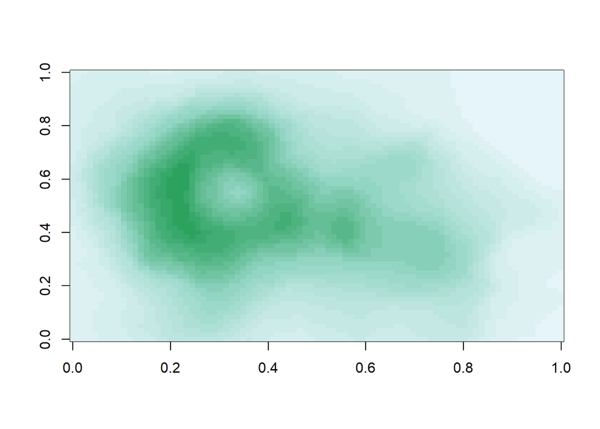

```r
pal <- colorRampPalette(cols)
image(volcano, col = pal(20))
```

### The smoothScatter function

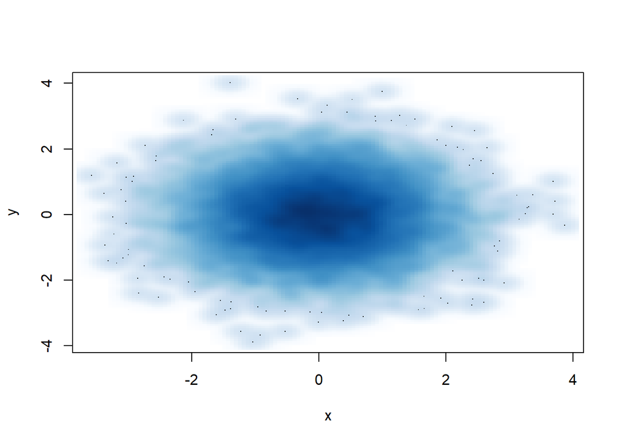

```r
x <- rnorm(10000)
y <- rnorm(10000)
smoothScatter(x, y)
```

## Some other plotting notes

- The rgb function can be used to produce any colour via proportions of red, green and blue
- Colour transparency can be added via the alpha parameter to rgb
- The **colorspace** package can be used for a different control over colours

### Scatterplot with no transparency

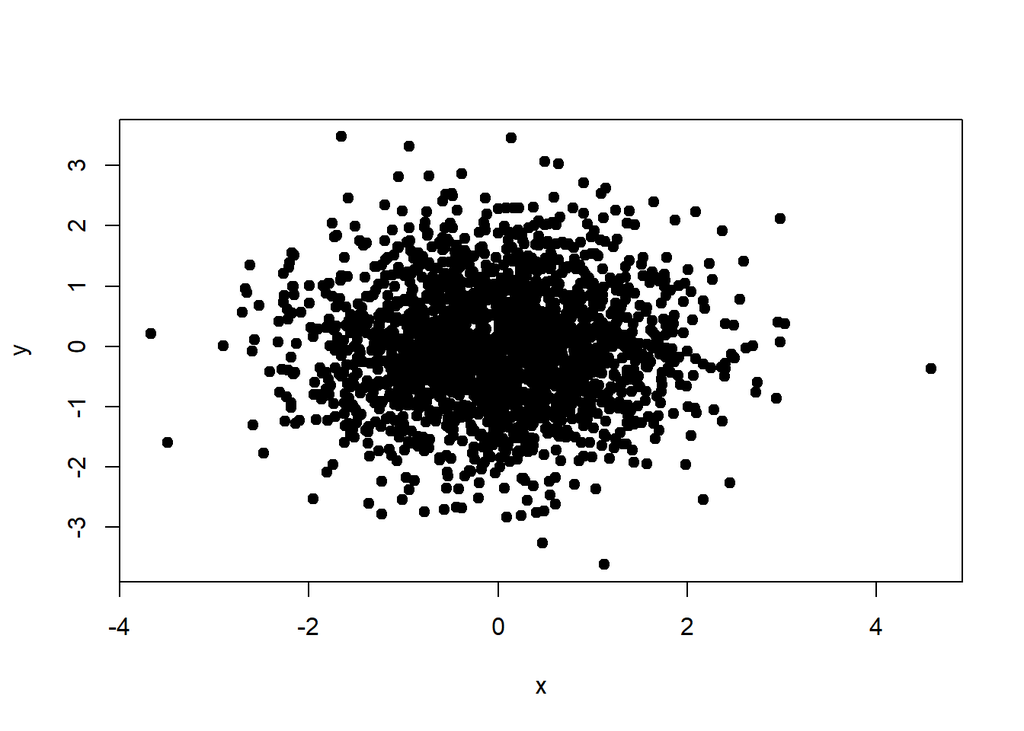

```r
x <- rnorm(2000)
y <- rnorm(2000)
plot(x, y, pch = 19)
```

### Scatterplot with tranparency

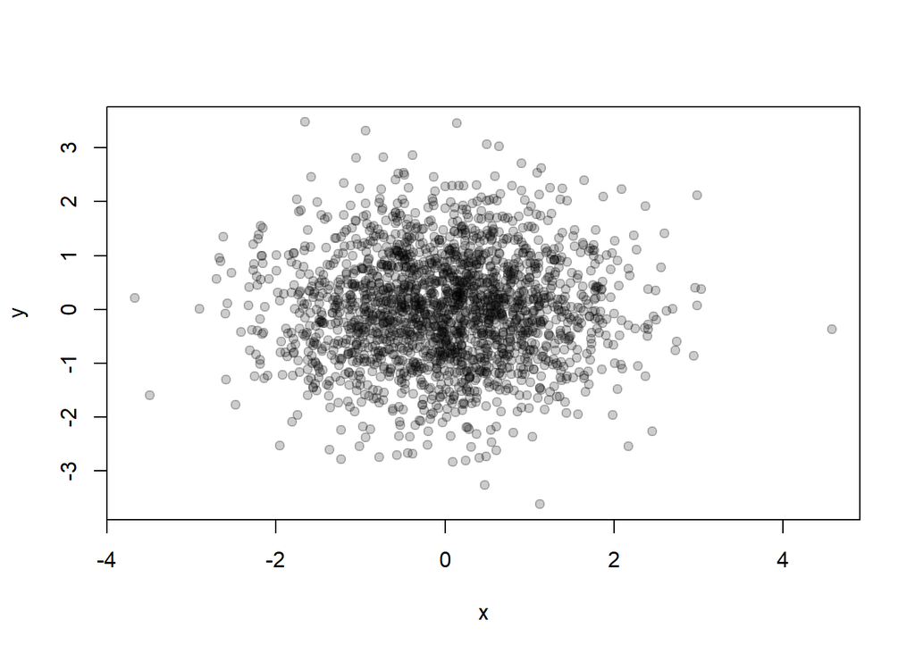

```r
plot(x, y, col = rgb(0, 0, 0, 0.2), pch = 19)
```

## Summary

- Careful use of colours in plots/maps/etc. can make it easier for the reader to get what you’re trying to say (why make it harder?)
- The **RColorBrewer** package is an R package that provides colour palettes for sequential, categorical and diverging data
- The colorRamp and colorRampPalette functions can be used in conjunction with colour palettes to connect data to colours
- Transparency can sometimes be used to clarify plots with many points